# Inspect Grit

Shantanu Singh

```
output:
  html_notebook:
    toc: true
    toc_float: true
    toc_depth: 3
    number_sections: true
    theme: lumen
```

```
output: github_document
```

# 1 Boilerplate

[output not shown]

If running interactively in RStudio,

- change `output` in the header of this markdown to `html_notebook` and
- change to `eval=TRUE` below

When knitting for pushing to GitHub,

- change `output` in the header of this markdown to `github_document` and
- change to `eval=FALSE` below

```r
show_table <- knitr::kable
knitr::opts_chunk$set(fig.width = 6, fig.asp = 2/3)
```

```r
library(magrittr)
library(tidyverse)
library(arrow)
```

# 2 Load data

Load EMPTY-normalized data

```r
metadata <- get_annotation(profiles)
```

```r
head(metadata, 5)
```

| id | Metadata_Plate | Metadata_Well | Metadata_WellCol | Metadata_WellRow | Metadata_cell_line | Metadata_gene_name | Metadata_pert_name |
| --- | --- | --- | --- | --- | --- | --- | --- |
| 1 | SQ00014618 | A01 | 1 | A | HCC44 | EMPTY | EMPTY |
| 2 | SQ00014618 | A02 | 2 | A | HCC44 | MCL1 | MCL1-5 |
| 3 | SQ00014618 | A03 | 3 | A | HCC44 | AKT1 | AKT1-1 |
| 4 | SQ00014618 | A04 | 4 | A | HCC44 | KRAS | KRAS-2B |
| 5 | SQ00014618 | A05 | 5 | A | HCC44 | AKT1 | AKT1-2 |

# 3 Calculate similarity

```r
sim_df <- sim_calculate(profiles)
```

# 4 Calculate

```r
annotation_cols <-
  c("Metadata_cell_line",
    "Metadata_gene_name",
    "Metadata_pert_name")
```

## 4.1 Drop some wells

```r
drop_group <-
  data.frame(Metadata_gene_name = "EMPTY")

if (!is.null(drop_group)) {
  sim_df %<>%
    sim_filter(filter_drop = drop_group, filter_side = "left") %>%
    sim_filter(filter_drop = drop_group, filter_side = "right")
}
```

## 4.2 Similarity to reference

Fetch similarities between

1. all rows (except, optionally those containing `reference`)

and

2. all rows containing `reference`

Do so only for those (a, b) pairs that

- have *same* values in *all* columns of `all_same_cols_ref`

```r
reference <-
  data.frame(Metadata_gene_name = c("Chr2", "Luc", "LacZ"))

drop_reference <- FALSE

all_same_cols_ref <-
  c("Metadata_cell_line",
    "Metadata_Plate")

ref <-
  sim_df %>%
  sim_all_same_keep_some(
    all_same_cols_ref,
    filter_keep_right = reference,
    drop_reference = drop_reference,
    annotation_cols =
      unique(c(annotation_cols, all_same_cols_ref))
  )
```

## 4.3 Similarity to group

Fetch similarities between

1. all rows

and

2. all rows

Do so only for those (a, b) pairs that

- have *same* values in *all* columns of `all_same_cols_group`
- have *different* values in *at least one* column of `any_different_cols_group`

```r
all_same_cols_group <-
  c("Metadata_cell_line",
    "Metadata_gene_name")

any_different_cols_group <-
  c("Metadata_cell_line",
    "Metadata_gene_name",
    "Metadata_pert_name")

rep_group <-
  sim_df %>%
  sim_some_different_drop_some(
    any_different_cols = any_different_cols_group,
    all_same_cols = all_same_cols_group)
```

## 4.4 Similarity to replicates (no references)

Fetch similarities between

1. all rows except `reference` rows

and

2. all rows except `reference` rows (i.e. to each other)

Do so for only those (a, b) pairs that

- have *same* values in *all* columns of `all_same_cols_rep

Keep, both, (a, b) and (b, a)

```r
all_same_cols_rep <-
  c("Metadata_cell_line",
    "Metadata_gene_name",
    "Metadata_pert_name")

rep <-
  sim_df %>%
  sim_filter(filter_drop = reference, filter_side = "left") %>%
  sim_filter(filter_drop = reference, filter_side = "right") %>%
  sim_all_same(all_same_cols_rep,
               annotation_cols,
               drop_lower = FALSE)
```

## 4.5 Similarity to replicates (only references)

Fetch similarities between

1. all rows containing `reference`

and

2. all rows containing `reference` (i.e. to each other)

Do so for only those (a, b) pairs that

- have *same* values in *all* columns of `all_same_cols_rep_ref`.

Keep, both, (a, b) and (b, a)

```r
all_same_cols_rep_ref <-
  c("Metadata_cell_line",
    "Metadata_gene_name",
    "Metadata_pert_name",
    "Metadata_Plate")

rep_ref <-
  sim_df %>%
  sim_filter(filter_keep = reference, filter_side = "left") %>%
  sim_filter(filter_keep = reference, filter_side = "right") %>%
  sim_all_same(
    all_same_cols_rep_ref,
    annotation_cols = all_same_cols_rep_ref,
    drop_lower = FALSE
  )
```

## 4.6 Similarity to non-replicates

Fetch similarities between

1. all rows (except, optionally, `reference` rows)

and

2. all rows except `reference` rows

Do so for only those (a, b) pairs that

- have *same* values in *all* columns of `all_same_cols_non_rep`
- have *different* values in *all* columns `all_different_cols_non_rep`
- have *different* values in *at least one* column of `any_different_cols_non_rep`

Keep, both, (a, b) and (b, a)

```r
any_different_cols_non_rep <-
  c("Metadata_cell_line",
    "Metadata_gene_name",
    "Metadata_pert_name")

all_same_cols_non_rep <-
  c("Metadata_cell_line", "Metadata_Plate")

all_different_cols_non_rep <-
  c("Metadata_gene_name")


if (drop_reference) {
  reference_left <- reference
} else {
  reference_left <- NULL
}

nonrep <-
  sim_df %>%
  sim_some_different_drop_some(
    any_different_cols = any_different_cols_non_rep,
    all_same_cols = all_same_cols_non_rep,
    all_different_cols = all_different_cols_non_rep,
    filter_drop_left = reference_left,
    filter_drop_right = reference
  )
```

# 5 Check

## 5.1 Similarity to reference

```r
# number of profiles
n_profiles <-
  profiles %>%
  group_by(across(all_of(c(all_same_cols_rep, all_same_cols_ref)))) %>%
  tally(name = "n_profiles") %>%
  arrange(desc(n_profiles))

if(drop_reference) {
  n_profiles %<>% anti_join(reference)
}

# number of references
n_references <-
  metadata %>%
  inner_join(reference, by = colnames(reference)) %>%
  group_by(across(all_of(all_same_cols_ref))) %>%
  tally(name = "n_references")

# number of pairs involving the reference (on the right column)
n_reference_pairs <-
  ref %>%
  group_by(across(all_of(c(all_same_cols_rep, all_same_cols_ref)))) %>%
  tally(name = "n_reference_pairs") %>%
  arrange(desc(n_reference_pairs))

# number of profiles x number of references = number of pairs involving the
# reference (on the right column)
check_df <-
  n_references %>%
  inner_join(n_reference_pairs, by = all_same_cols_ref) %>%
  inner_join(n_profiles, by = unique(c(all_same_cols_rep, all_same_cols_ref)))

stopifnot(check_df %>%
            mutate(check =
                     n_reference_pairs == (n_profiles * n_references)) %>%
            anti_join(reference) %>%
            filter(!check) %>%
            nrow() == 0)
stopifnot(check_df %>%
            mutate(check =
                     n_reference_pairs == (n_profiles * n_references) - n_profiles) %>%
            inner_join(reference) %>%
            filter(!check) %>%
            nrow() == 0)
```

## 5.2 Similarity to replicates (no references)

```r
n_profiles <-
  profiles %>%
  anti_join(reference, by = colnames(reference)) %>%
  group_by(across(all_of(all_same_cols_rep))) %>%
  tally(name = "n_profiles") %>%
  arrange(desc(n_profiles))

n_replicate_pairs <-
  rep %>%
  group_by(across(all_of(annotation_cols))) %>%
  tally(name = "n_replicate_pairs") %>%
  arrange(desc(n_replicate_pairs))

stopifnot(
  inner_join(n_profiles, n_replicate_pairs, by = all_same_cols_rep) %>%
    mutate(check =
             n_replicate_pairs == n_profiles * (n_profiles - 1)) %>%
    filter(!check) %>%
    nrow() == 0
)
```

## 5.3 Similarity to nonreplicates

```r
nonrep_annotated <-
  nonrep %>%
  sim_annotate(
    annotation_cols = c(annotation_cols, "Metadata_Plate", "Metadata_Well"),
    index = "both"
  )

walk(all_same_cols_non_rep,
     function(x) {
       x1 <- paste0(x, "1")
       x2 <- paste0(x, "2")
       # by definition of all_same_cols
       stopifnot(nonrep_annotated %>% filter(.data[[x1]] != .data[[x2]]) %>% nrow() == 0)
     })


walk(all_different_cols_non_rep,
     function(x) {
       x1 <- paste0(x, "1")
       x2 <- paste0(x, "2")
       # by definition of all_different_cols
       stopifnot(nonrep_annotated %>% filter(.data[[x1]] == .data[[x2]]) %>% nrow() == 0)
     })

# by definition of any_different_cols
# any_different is identical to not_all_same
stopifnot(
  nonrep_annotated %>%
    unite(
      "any_different_col1",
      all_of(paste0(any_different_cols_non_rep, "1")),
      sep = ":",
      remove = FALSE
    ) %>%
    unite(
      "any_different_col2",
      all_of(paste0(any_different_cols_non_rep, "2")),
      sep = ":",
      remove = FALSE
    ) %>%
    filter(any_different_col1 == any_different_col2) %>%
    nrow() == 0
)
```

## 5.4 Similarity to group

```r
repgroup_annotated <-
  rep_group %>%
  sim_annotate(
    annotation_cols = annotation_cols,
    index = "both"
  )

walk(all_same_cols_group,
     function(x) {
       x1 <- paste0(x, "1")
       x2 <- paste0(x, "2")
       # by definition of all_same_cols
       stopifnot(repgroup_annotated %>% filter(.data[[x1]] != .data[[x2]]) %>% nrow() == 0)
     })

# by definition of any_different_cols
# any_different is identical to not_all_same
stopifnot(
  repgroup_annotated %>%
    unite(
      "any_different_col1",
      all_of(paste0(any_different_cols_group, "1")),
      sep = ":",
      remove = FALSE
    ) %>%
    unite(
      "any_different_col2",
      all_of(paste0(any_different_cols_group, "2")),
      sep = ":",
      remove = FALSE
    ) %>%
    filter(any_different_col1 == any_different_col2) %>%
    nrow() == 0
)
```

```r
repgroup_annotated %>%
  group_by(across(all_of(paste0(all_same_cols_group, "1")))) %>%
  tally()
```

| Metadata_cell_line1 | Metadata_gene_name1 | n |
| --- | --- | --- |
| A549 | AKT1 | 72 |
| A549 | ARID1B | 72 |
| A549 | ATF4 | 72 |
| A549 | ATP50 | 72 |
| A549 | BCL2 | 72 |
| A549 | BCL2L2 | 216 |
| A549 | BRCA1 | 72 |
| A549 | BRD4 | 72 |
| A549 | CCND1 | 72 |
| A549 | CCNE1 | 72 |

[output cut: 149 more lines]

# 6 Inspect

## 6.1 Similarity to replicates (no references)

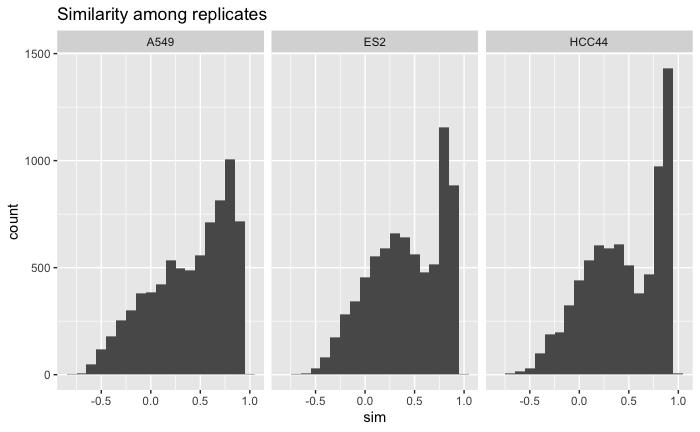

```r
rep %>%
  ggplot(aes(sim)) +
  geom_histogram(binwidth = .1) +
  facet_wrap(~Metadata_cell_line) +
  ggtitle("Similarity among replicates")
```

## 6.2 Similarity to group

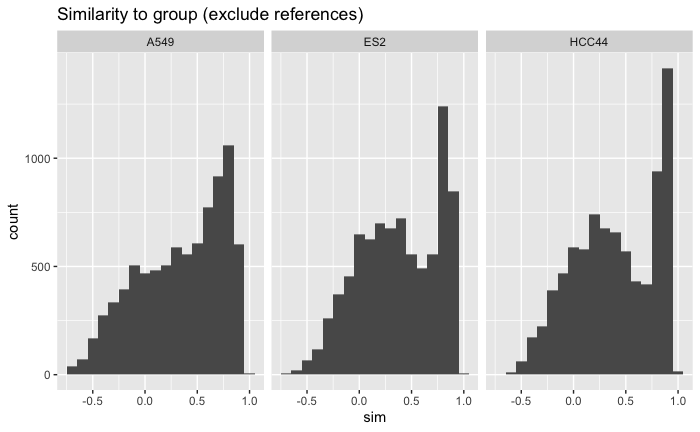

```r
repgroup_annotated <-
  rep_group %>%
  sim_annotate(
    annotation_cols = annotation_cols,
    index = "left"
  )

repgroup_annotated %>%
  anti_join(reference, by = colnames(reference)) %>%
  ggplot(aes(sim)) +
  geom_histogram(binwidth = .1) +
  facet_wrap(~Metadata_cell_line) +
  ggtitle("Similarity to group (exclude references)")
```

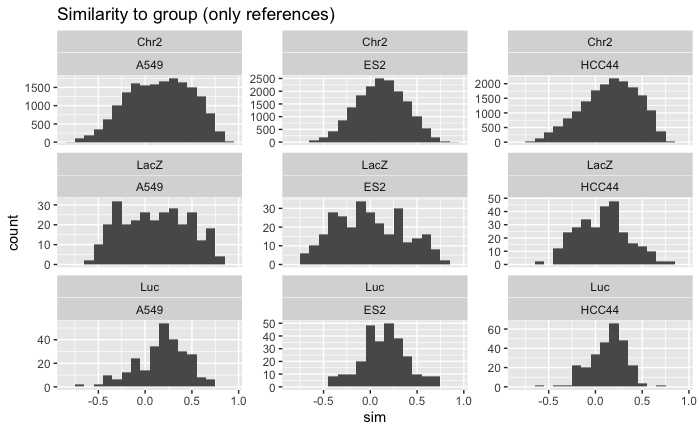

```r
repgroup_annotated %>%
  inner_join(reference, by = colnames(reference)) %>%
  ggplot(aes(sim)) +
  geom_histogram(binwidth = .1) +
  facet_wrap(Metadata_gene_name~Metadata_cell_line, scales = "free_y") +
  ggtitle("Similarity to group (only references)")
```

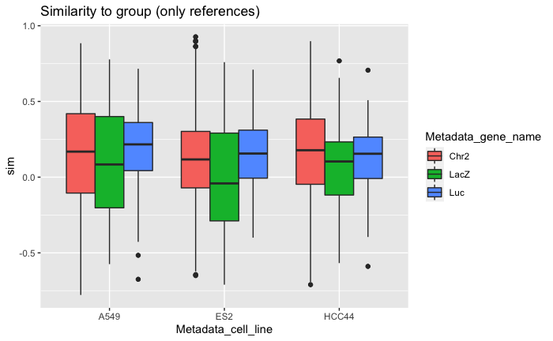

```r
repgroup_annotated %>%
  inner_join(reference, by = colnames(reference)) %>%
  ggplot(aes(Metadata_cell_line, sim, fill = Metadata_gene_name)) +
  geom_boxplot( position = "dodge") +
  ggtitle("Similarity to group (only references)")
```

```r
repgroup_annotated %>%
  inner_join(reference, by = colnames(reference)) %>%
  group_by(Metadata_cell_line) %>%
  summarise(across(all_of("sim"), list(mean = mean, sd = sd)))
```

| Metadata_cell_line | sim_mean | sim_sd |
| --- | --- | --- |
| A549 | 0.1526655 | 0.3362584 |
| ES2 | 0.1130374 | 0.2639875 |
| HCC44 | 0.1536623 | 0.2946616 |

```r
NA
```

## 6.3 Similarity to replicates (only references)

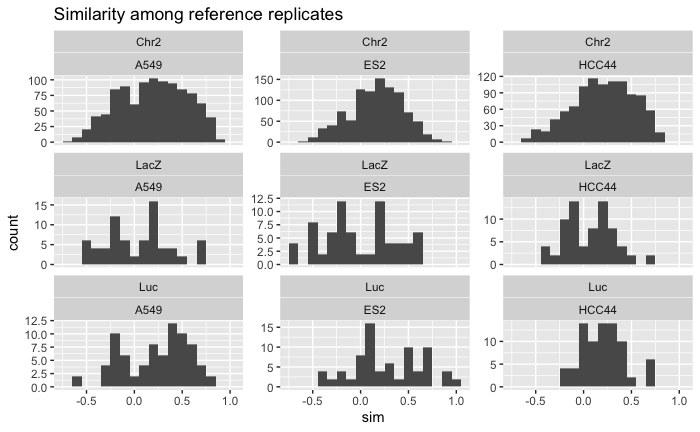

```r
rep_ref %>%
  ggplot(aes(sim)) +
  geom_histogram(binwidth = .1) +
  facet_wrap(Metadata_gene_name~Metadata_cell_line, scales = "free_y") +
  ggtitle("Similarity among reference replicates")
```

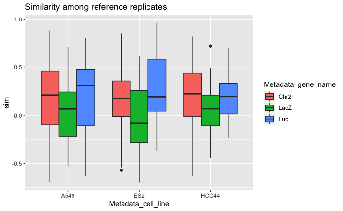

```r
rep_ref %>%
  ggplot(aes(Metadata_cell_line, sim, fill = Metadata_gene_name)) +
  geom_boxplot( position = "dodge") +
  ggtitle("Similarity among reference replicates")
```

```r
rep_ref %>%
  group_by(Metadata_cell_line) %>%
  summarise(across(all_of("sim"), list(mean = mean, sd = sd)))
```

| Metadata_cell_line | sim_mean | sim_sd |
| --- | --- | --- |
| A549 | 0.1834861 | 0.3513287 |
| ES2 | 0.1569321 | 0.2951124 |
| HCC44 | 0.1938058 | 0.3083998 |

## 6.4 Similarity to reference

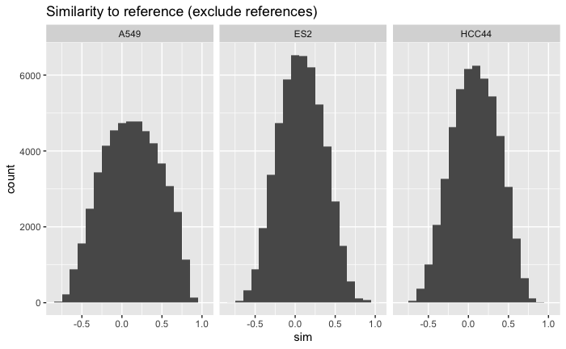

```r
ref %>%
  anti_join(reference) %>%
  ggplot(aes(sim)) +
  geom_histogram(binwidth = .1) +
  facet_wrap(~Metadata_cell_line) +
  ggtitle("Similarity to reference (exclude references)")
```

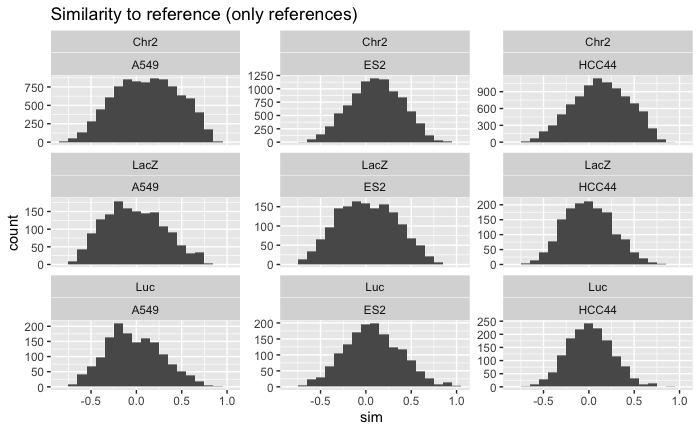

```r
ref %>%
  inner_join(reference) %>%
  ggplot(aes(sim)) +
  geom_histogram(binwidth = .1) +
  facet_wrap(Metadata_gene_name~Metadata_cell_line, scales = "free_y") +
  ggtitle("Similarity to reference (only references)")
```

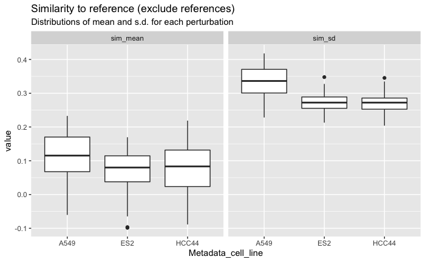

```r
ref %>%
  anti_join(reference, by = colnames(reference)) %>%
  group_by(across(all_of(annotation_cols))) %>%
  summarise(across(all_of("sim"), list(mean = mean, sd = sd)), .groups = "keep") %>%
  ungroup() %>%
  pivot_longer(-any_of(annotation_cols)) %>%
  ggplot(aes(Metadata_cell_line, value)) + geom_boxplot() +
  facet_wrap(~name) +
  ggtitle("Similarity to reference (exclude references)",
          subtitle = "Distributions of mean and s.d. for each perturbation")
```

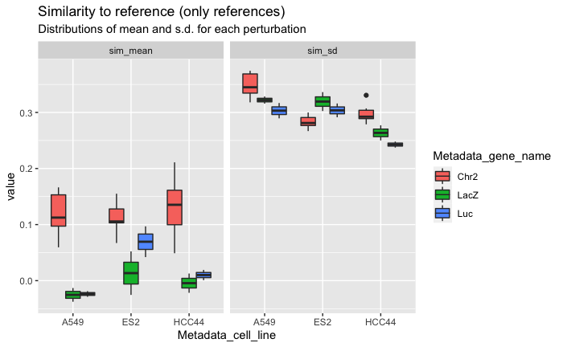

```r
ref %>%
  inner_join(reference, by = colnames(reference)) %>%
  group_by(across(all_of(annotation_cols))) %>%
  summarise(across(all_of("sim"), list(mean = mean, sd = sd)), .groups = "keep") %>%
  ungroup() %>%
  pivot_longer(-any_of(annotation_cols)) %>%
  ggplot(aes(Metadata_cell_line, value, fill = Metadata_gene_name)) + geom_boxplot(position = "dodge") +
  facet_wrap(~name) +
  ggtitle("Similarity to reference (only references)",
          subtitle = "Distributions of mean and s.d. for each perturbation")
```

## 6.5 Similarity to non-replicates

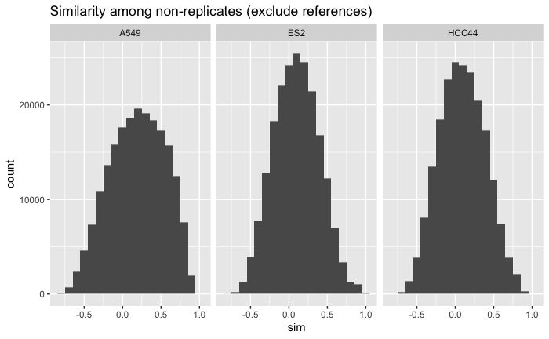

```r
nonrep_annotated <-
  nonrep %>%
  sim_annotate(annotation_cols = c(annotation_cols),
               index = "left")

nonrep_annotated %>%
  anti_join(reference, by = colnames(reference)) %>%
  ggplot(aes(sim)) +
  geom_histogram(binwidth = .1) +
  facet_wrap(~Metadata_cell_line) +
  ggtitle("Similarity among non-replicates (exclude references)")
```

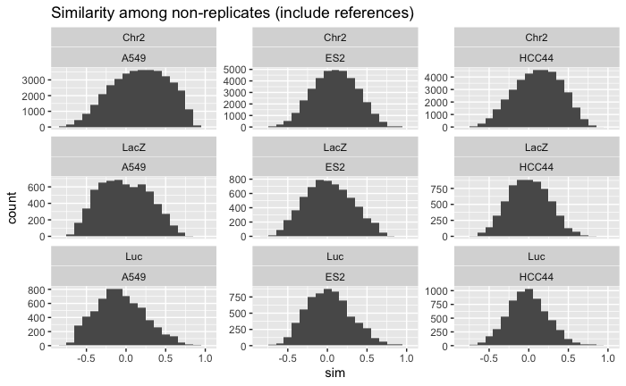

```r
nonrep_annotated %>%
  inner_join(reference, by = colnames(reference)) %>%
  ggplot(aes(sim)) +
  geom_histogram(binwidth = .1) +
  facet_wrap(Metadata_gene_name~Metadata_cell_line, scales = "free_y") +
  ggtitle("Similarity among non-replicates (include references)")
```

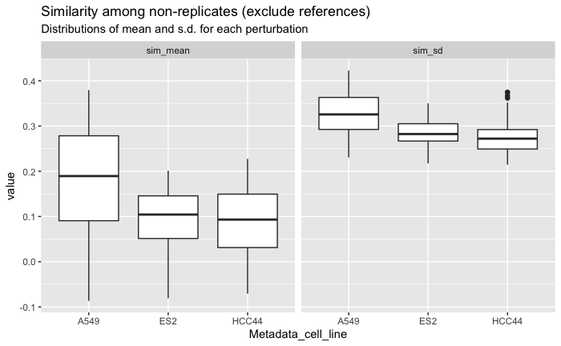

```r
nonrep_annotated %>%
  anti_join(reference, by = colnames(reference)) %>%
  group_by(across(all_of(annotation_cols))) %>%
  summarise(across(all_of("sim"), list(mean = mean, sd = sd)), .groups = "keep") %>%
  pivot_longer(-any_of(annotation_cols)) %>%
  ggplot(aes(Metadata_cell_line, value)) + geom_boxplot() +
  facet_wrap(~name) +
  ggtitle("Similarity among non-replicates (exclude references)",
          subtitle = "Distributions of mean and s.d. for each perturbation")
```

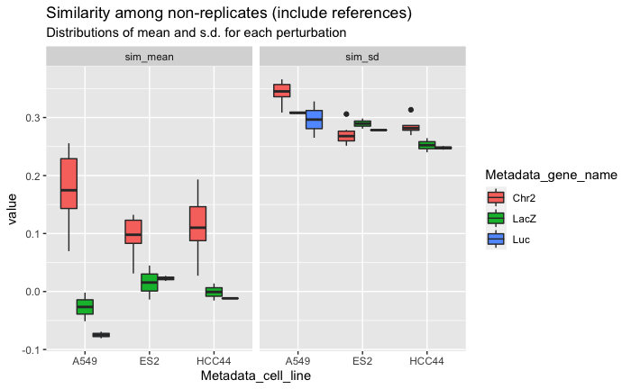

```r
nonrep_annotated %>%
  inner_join(reference, by = colnames(reference)) %>%
  group_by(across(all_of(annotation_cols))) %>%
  summarise(across(all_of("sim"), list(mean = mean, sd = sd)), .groups = "keep") %>%
  ungroup() %>%
  pivot_longer(-any_of(annotation_cols)) %>%
  ggplot(aes(Metadata_cell_line, value, fill = Metadata_gene_name)) +
  geom_boxplot(position = "dodge") +
  facet_wrap(~name) +
  ggtitle("Similarity among non-replicates (include references)",
          subtitle = "Distributions of mean and s.d. for each perturbation")
```